# Assignment 3

## `i` Changes to `Jags-Ydich-XnomSsubj-MbinomBetaOmegaKappa-Power-2.R`

```r
# Changed in 'Jags-Ydich-XnomSsubj-MbinomBetaOmegaKappa-Power-2.R'...
# Assumes changes from last part

# Specify criteria for goals:
nullROPE = c(0.48,0.52)
HDImaxWid = 0.1

# Specify sample size for each simulated data set:
Nsubj = 40 ; NtrlPerSubj = 100
#Nsubj = 2*7 ; NtrlPerSubj = 47 # 658 flips total
nSimulatedDataSets = 20 # still 1 since takes too long to run for an exercise
```

```r
# Note the -2 at end of file name
source('Jags-Ydich-XnomSsubj-MbinomBetaOmegaKappa-Power-2.R')
```

[output not shown]

[output not shown]

[output cut: 649 more lines]

```
## ************************************************** 100%
## . . . . Updating 0
## . Deleting model
## .
## All chains have finished
## Simulation complete.  Reading coda files...
## Coda files loaded successfully
## Finished running the simulation
##      theta[1] theta[2] theta[3] theta[4] theta[5]
## [1,] 0.344458 0.249899 0.264682 0.298187 0.264530
## [2,] 0.505544 0.404021 0.424014 0.457637 0.424197
## [1] "omegaAboveROPE: Est.Power=0; Low Bound=0; High Bound=0.133"
## [1] "omegaNarrowHDI: Est.Power=1; Low Bound=0.867; High Bound=1"
## [1] "thetasAboveROPE: Est.Power=0; Low Bound=0; High Bound=0.133"
## [1] "thetasNarrowHDI: Est.Power=0; Low Bound=0; High Bound=0.133"
```

### Question:

- `omegaNarrowHDI` has high power because there are 40 subjects.
- This allows for a constent group-level estimate of omega that is decently certain (HDI width less than 0.1)
- However, `thetasNarrowHDI` has low power since 100 trials per subject usually yields HDIs on individual theta’s such that at least one of them has width greater than 0.1.

## `j`

### Changes to `Jags-Ydich-XnomSsubj-MbinomBetaOmegaKappa-Power-3.R`

```r
# Changed in 'Jags-Ydich-XnomSsubj-MbinomBetaOmegaKappa-Power-3.R'...
# Assumes changes from last part

idealDatFrm = data.frame(dataMat)
idealDatFrm = read.csv("TherapeuticTouchData.csv") # overwrites previous idealDatFrm
# Run Bayesian analysis on idealized data:
mcmcCoda = genMCMC( data=idealDatFrm , saveName=NULL ,
 numSavedSteps=2000 , thinSteps=20 )
```

### Run the model

```r
# Note the -3 at end of file name
source('Jags-Ydich-XnomSsubj-MbinomBetaOmegaKappa-Power-3.R')
```

[output not shown]

[output not shown]

[output cut: 649 more lines]

```
## ************************************************** 100%
## . . . . Updating 0
## . Deleting model
## .
## All chains have finished
## Simulation complete.  Reading coda files...
## Coda files loaded successfully
## Finished running the simulation
##      theta[1] theta[2] theta[3] theta[4] theta[5]
## [1,] 0.400718 0.654967 0.221971 0.376393 0.144623
## [2,] 0.587841 0.820118 0.393201 0.567670 0.295513
## [1] "omegaAboveROPE: Est.Power=0; Low Bound=0; High Bound=0.133"
## [1] "omegaNarrowHDI: Est.Power=0.45; Low Bound=0.254; High Bound=0.657"
## [1] "thetasAboveROPE: Est.Power=0; Low Bound=0; High Bound=0.133"
## [1] "thetasNarrowHDI: Est.Power=0; Low Bound=0; High Bound=0.133"
```

# Task 6

## `a` Proposal Function `myprop()`

```r
# Function to sample n tosses with head proposed has a probability p
# proposed 2-values in vector. First value is success, second is failure
myprop <- function(n, p, proposed=c(0.3, 0.6)){
  proposalDist <- sample(proposed, size = n,
                         replace = TRUE, prob = c(p, 1-p))

  return(list('proposalDist' = proposalDist, 'n'=n, 'p'=p))
}
```

## `b` Call `myprop()`

```r
# Proposed c(0.3, 0.6) by default...
myprop(n=10,  p=0.5) #  10 tosses with probability of success being 0.5
```

```
## $proposalDist
##  [1] 0.6 0.3 0.6 0.6 0.6 0.6 0.3 0.3 0.6 0.6
##
## $n
## [1] 10
##
## $p
## [1] 0.5
```

```r
myprop(n=20,  p=0.1) #  20 tosses with probability of success being 0.1
```

```
## $proposalDist
##  [1] 0.3 0.6 0.6 0.6 0.6 0.6 0.6 0.6 0.6 0.6 0.3 0.6 0.6 0.6 0.6 0.3 0.6 0.6 0.6
## [20] 0.6
##
## $n
## [1] 20
##
## $p
## [1] 0.1
```

```r
myprop(n=100, p=0.4) # 100 tosses with probability of success being 0.4
```

```
## $proposalDist
##   [1] 0.6 0.6 0.6 0.6 0.6 0.3 0.6 0.3 0.6 0.3 0.6 0.3 0.6 0.3 0.3 0.6 0.3 0.3
##  [19] 0.6 0.3 0.6 0.6 0.6 0.6 0.6 0.3 0.3 0.3 0.6 0.3 0.3 0.6 0.6 0.3 0.3 0.6
##  [37] 0.3 0.3 0.3 0.3 0.6 0.3 0.6 0.6 0.6 0.3 0.6 0.6 0.3 0.6 0.6 0.3 0.3 0.3
##  [55] 0.6 0.6 0.3 0.6 0.3 0.3 0.6 0.6 0.3 0.3 0.6 0.6 0.3 0.3 0.3 0.3 0.6 0.6
##  [73] 0.6 0.3 0.6 0.6 0.6 0.6 0.3 0.3 0.6 0.3 0.3 0.6 0.6 0.3 0.6 0.3 0.6 0.6
##  [91] 0.6 0.6 0.6 0.3 0.6 0.6 0.6 0.3 0.6 0.6
##
## $n
## [1] 100
##
## $p
## [1] 0.4
```

## `c` Barplot of `myprop()`

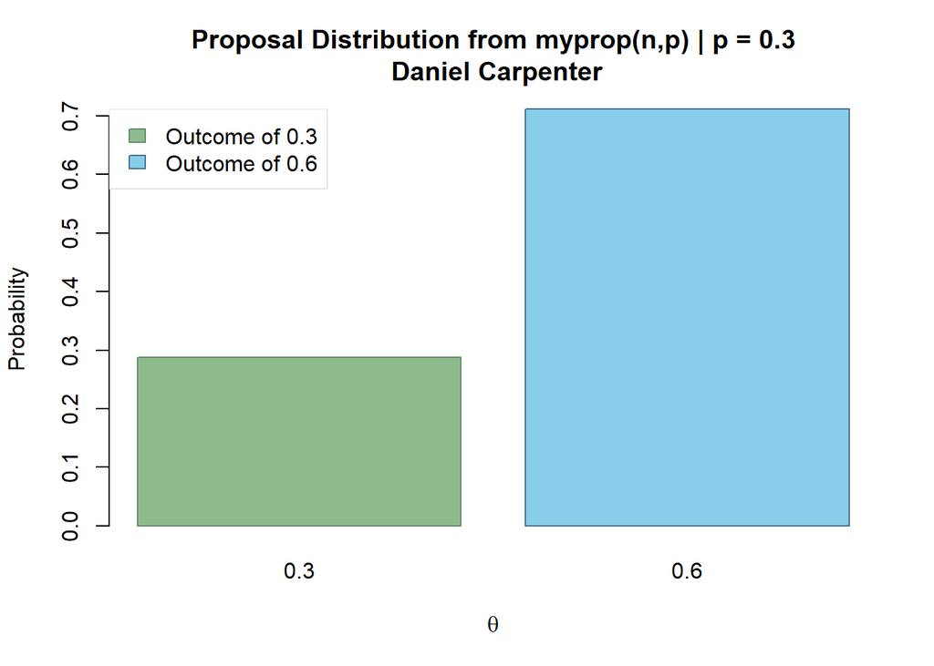

```r
# Create a bar plot given the output of a myprop function
createBarPlot <- function(myprop) {

  # Colors to reuse
  fillColor   = c('darkseagreen', 'skyblue')
  borderColor = c('darkseagreen4', 'skyblue4')

  # Create the barplot
  barplot(table(myprop$proposalDist) / myprop$n,
          main = paste0('Proposal Distribution from myprop(n,p) | p = ',myprop$p,'\n Daniel Carpenter'),
          col  = fillColor, border = borderColor,
          xlab = expression(theta), ylab = 'Probability')

  # Create the legend
  legend('topleft', legend=c("Outcome of 0.3", "Outcome of 0.6"),
         bty = 1, fill=fillColor, border=borderColor, box.col = 'grey90')
}

n = 1000 # number of tosses
p = 0.3  # Probability of a success, in this case is outcome of 0.3

# Call the bar plot function
# Note proposed c(0.3, 0.6) by default...
theProposal <- myprop(n, p)
createBarPlot(theProposal)
```

## `d` Binomial Liklihood Formula $p(x \mid \theta)$

$$p(x \mid \theta) = \left(\begin{array}{l}n \\ x\end{array}\right) \theta^{x}(1-\theta)^{n-x}$$

## `e` Use Beta Prior $p(\theta)$ and $p(x \mid \theta)$ to get $h(\theta)$

### Beta distribution definition p()

$$p(\theta) = \frac{1}{B(\alpha, \beta)} \theta^{\alpha-1}(1-\theta)^{\beta-1}$$

### $h(\theta)$: Beta Prior $\times$ Binomial Likelihood

> Note the parameter values are $\alpha = \beta = 2$ in this example

$$h(\theta) = p(\theta) p(x \mid \theta)$$

### $h(\theta)$ Explicitly stated

$$h(\theta) =
\frac{1}{B(\alpha, \beta)} \theta^{\alpha-1}(1-\theta)^{\beta-1}
\times
\left(\begin{array}{l}n \\ x\end{array}\right) \theta^{x}(1-\theta)^{n-x}$$

## `f` Acceptance Equation using $h(\theta)$

$$\alpha_{i, j}=\min \left\{1, \frac{h_{j}}{h_{i}}\right\}$$

## `g` Create function `mymcmc()`

```r
mymcmc <- function(n=10000, h, p=0.5, proposed, ...){

  # Function to sample n tosses with head proposed has a probability p
  # proposed 2-values in vector. First value is success, second is failure
  myprop <- function(n, p, proposed){
    proposalDist <- sample(proposed, size = n,
                           replace = TRUE, prob = c(p, 1-p))

    return(list('proposalDist' = proposalDist, 'n'=n, 'p'=p))
  }
  alpha<-c() # holds transition probs
  alpha[1]<-1
  u<-c() # holds uniform values
  u[1]<-1
  post<-c()# post sample
  prop<-c() # vec of proposed states 1s and 2s
  prop[1]=proposed[1] # initial state
  post[1]=prop[1]

  for(i in 2:n){ # starts at 2 because initial value given above
    # proposal state
    prop[i]=myprop(n=1, p=p, proposed=proposed)$proposalDist

    # calculate alpha
    # notice h[prop[i]] gives the actual value of h
    alpha[i]=min(1,h[prop[i]]/h[post[i-1]])

    # to calculate accepting proposal with prob alpha
    # select a random value from  a uniform (0,1)
    u[i]=runif(1)
    if(u[i]<=alpha[i]){post[i]<-prop[i]}
    else{post[i]<-post[i-1]}
  }
  res<-matrix(c(prop,u,alpha,post ),nc=4,nr=n,byrow=FALSE)
  sim<-table(post)/n
  # windows only works with a pc
  # quartz with macs
  # dev.new(noRStudioGD = TRUE) # or quartz()

  postexact<-h/sum(h)


  # PLOTS ======================================================================

  require(tidyverse)
  require(ggplot2)

  # Create a simple theme for reuse
  myTheme <- theme_minimal() + theme(text = element_text(color = '#666666'),
                                     panel.grid.major = element_blank())


  # Make the iter vector a data frame
  iterOut <- as.data.frame(res) %>%
    mutate(numIterations = row_number())



  # Show Proposal  -------------------------------------------------------------
  propPlot <- ggplot(data.frame(table(prop)/n),
                     aes(x=prop, y = Freq)) +

    # COlumn Chart of the post estimated
    geom_col( fill="lightblue", colour="lightblue4", alpha = 0.5) +

    # Theme
    myTheme +

    # Labels
    labs(title = 'Proposal', y = "Probability", x = expression(theta) )


  # Posterior simulation ------------------------------------------------------
  postPlot <- ggplot(data.frame(table(post)/n),
                     aes(x=post, y = Freq)) +

    # COlumn Chart of the post estimated
    geom_col( fill="tomato3", colour="tomato4", alpha = 0.5) +

    # Theme
    myTheme +

    # Labels
    labs(title = "Posterior", y = "Probability", x = expression(theta) )


  # Posterior Trace Plot  ------------------------------------------------------
  tracePostPlot <- ggplot(data=iterOut,
                          aes(x=numIterations, y=V4)) +

    # Add the lines
    geom_line(color='grey75', alpha = 0.7) +

    # Add some points
    geom_point(color = 'grey40', size = 0.25, alpha = 0.1) +

    # Theme and Labels
    myTheme +
    labs(title = "Trace Plot", x = "Iterations", y = expression(theta) )


  # Print the plots on single grid ---------------------------------------------
  require(cowplot) # allows for plotting on single grid using plot_grid())
  print(plot_grid(propPlot, postPlot, tracePostPlot,
            nrow = 1, rel_widths = c(1,1,2)))


  # The returned output is a list
  # Use obj$ to obtain whatever interests you
  return(list(iter=res,sim=sim,postexact=postexact,post=post) )
}
```

## `h` Call function `mymcmc()`

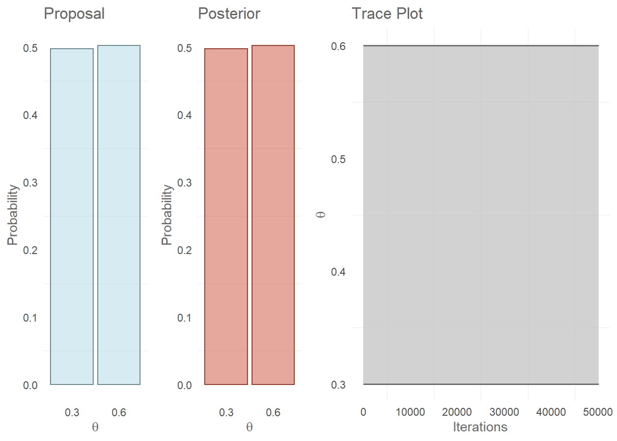

```r
# Create a function to get a bernnouli lik and beta prior
getBernBetaH <- function(numThetaValues,
                         x, n,
                         shape1=2, shape2=2) {

  ## Form uniform probability
  theta <- seq(0, 1, length = numThetaValues)

  ## Calculate prior assuming uniform distribution
  prior = dbeta(theta, shape1, shape2)

  ## Calculate the likelihood
  likelihood  = dbinom(x=x, size=n, prob=theta)

  ## Calculate the Prior x the Likelihood
  h <-  prior * likelihood

  return(h)
}


# Inputs for getBernBetaH()
numThetaValues = 1000

# Proposal Inputs
p=0.5
proposed=c(0.3,0.6)

# Beta prior inputs
shape1 = 2
shape2 = 2

# Bernoulli Likelihood inputs
x = 4
n = 10

# h: prior x likelihood using beta prior and bernoulli likelihood
h=getBernBetaH(numThetaValues, x, n, shape1,shape2)

# Call mydmcmc and add some extras to the plot
obj <- mymcmc(n=50000, h, p=0.5, proposed=c(0.3,0.6))
```

```r
# head(obj) # not required since prints already
```